# MYGA Customer Analysis

Paul Tyler

April 3, 2016

## Sales Volume

This file includes records of 5,970 applications that represented $532.5 million in premiums. Each sale averaged just under $90,000. The median case size was $50,000. Though we saw a wide range of case sizes, we did see four meaningful clusters at $25,000, $50,000, $100,000 and $150,000.

|  | x |
| --- | --- |
| Cases | 5970 |
| Total_Premium | 532508630 |
| Avg_Premium | 89197 |
| Med_Premium | 50000 |

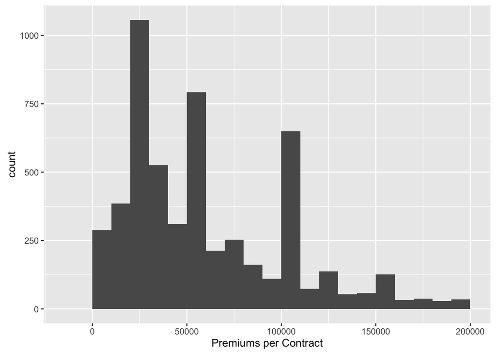

## Net Worth of Consumers

A few customers reported very large networths and pushed the average networth to $1.5 million. We think the median networth of slightly less than $1 million - $995,000 - presents a truer picture. Roughly half the assets are liquid and the other half is illiquid.

|  | x |
| --- | --- |
| mean_assets | 1486247 |
| mean_liq_assets | 759464 |
| mean_non_liq_assets | 725579 |
| median_assets | 995000 |
| median_liq_assets | 465000 |
| median_non_liq_assets | 431500 |

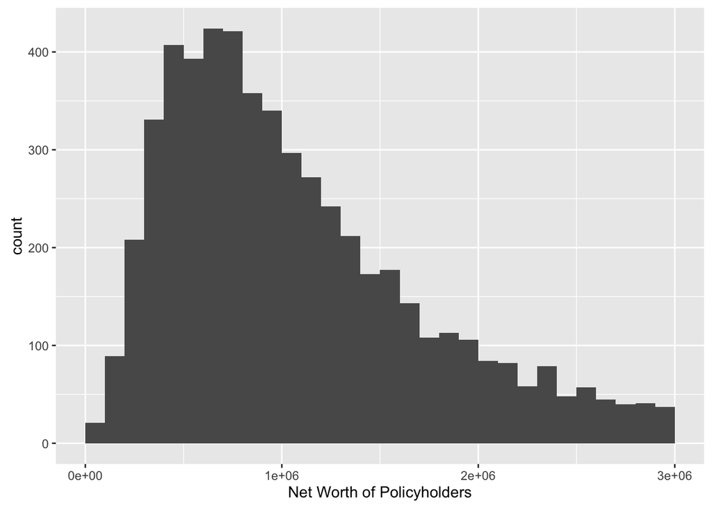

## Source of Net Worth

The largest source of net worth reported by clients was their home, their qualified retirement plan, and their checking or money market account, in that order. The vast majority of the money used to purchase the annuity came from liquid sources.

|  | Avg_Liq_Src | Avg_Non_Liq_Src |
| --- | --- | --- |
| 1 | 0.93 | 0.07 |

#### Liquid Assets

Most of the liquid net worth comes first from a qualified plan (i.e. IRA, 401(k)) and then from a checking or money market account. Some large outliers in all categories distort the average amount.

```
##              [,1]      [,2]
## Value        "Average" "Median"
## Cash         "54080"   " 2000"
## Checking     "145410"  " 68000"
## CDs          "76034"   "    0"
## IRAs         "202732"  " 76000"
## Stocks_Bonds "96529"   "    0"
## Mutual_Funds "66449"   "    0"
## Annuities    "87883"   "    0"
## Life_Ins     "14453"   "    0"
## Other        "14812"   "    0"
```

#### Non-Liquid Assets

The house is typically the major non-liquid asset reported by clients.

```
##               [,1]      [,2]
## Value         "Average" "Median"
## Val_of_Home   "296288"  "230000"
## Other_RE      "200248"  "     0"
## IRA_under     "52937"   "    0"
## Class_B_MF    "2406"    "   0"
## Gold          "11468"   "    0"
## Ann_with_Pen  "134562"  "     0"
## Life_with_Pen "4292"    "   0"
## Other_Non_Liq "23378"   "    0"
```

## Home Values

The average value of the home was close to $300,000. The median was exactly $230,000.

|  | x |
| --- | --- |
| minimum | 0 |
| mean | 296288 |
| median | 230000 |
| maximum | 6000000 |

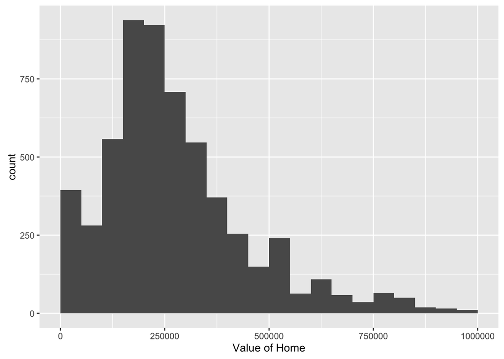

## Age

We received the age of owners for the latest MYGA program. The average age of our client is 68 and the oldest was 90.

|  | Avg_age | Med_age | Max_age |
| --- | --- | --- | --- |
| 1 | 68.3 | 68 | 90 |

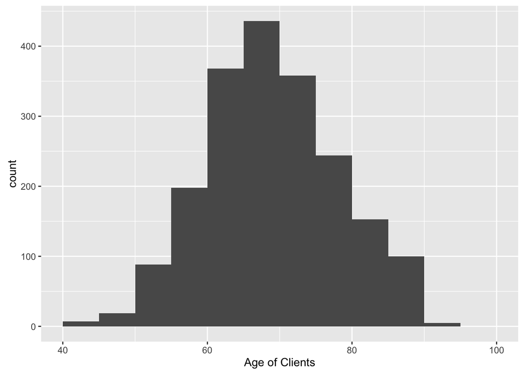

We saw little difference in average case size in any age band.

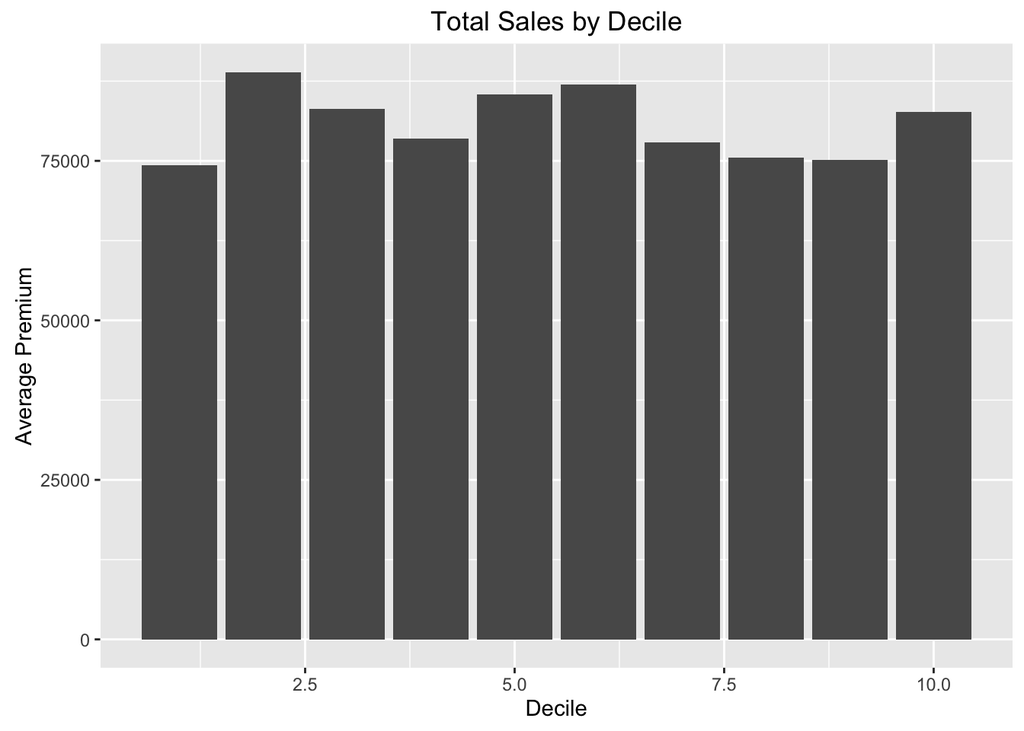

|  | Decile_Age | Min_age | Max_age | Avg_case | Total_sales | Tot_Cases |
| --- | --- | --- | --- | --- | --- | --- |
| 1 | 1 | 2 | 57 | 74328 | 14791242 | 199 |
| 2 | 2 | 57 | 61 | 88920 | 17695046 | 199 |
| 3 | 3 | 61 | 63 | 83200 | 16556726 | 199 |
| 4 | 4 | 63 | 66 | 78430 | 15529202 | 198 |
| 5 | 5 | 66 | 68 | 85402 | 16995044 | 199 |
| 6 | 6 | 68 | 70 | 86987 | 17310328 | 199 |
| 7 | 7 | 71 | 73 | 77899 | 15424065 | 198 |
| 8 | 8 | 73 | 77 | 75490 | 15022453 | 199 |
| 9 | 9 | 77 | 81 | 75107 | 14946350 | 199 |
| 10 | 10 | 81 | 90 | 82689 | 16372391 | 198 |

## Discretionary Income

We ask applicants for their monthly income and monthly expenses. The difference or median discretionary income to spend is $2,500.

|  | x |
| --- | --- |
| minimum_discr | -55000 |
| mean_discr | 5410 |
| median_discr | 2500 |
| maximum_discr | 983000 |

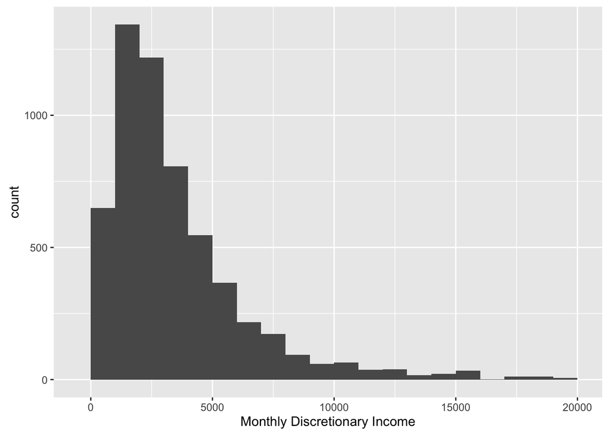

## Work Status

Close to 70% owners as well as any joint owners reported they were “retired.” Slightly more than 30% indicated they were employed.

#### Owner

|  | ct | status | n | pct |
| --- | --- | --- | --- | --- |
| 1 | 1.00 | Retired | 4011 | 0.67 |
| 2 | 2.00 | Employed | 1843 | 0.31 |
| 3 | 3.00 | Unemployed | 45 | 0.01 |
| 4 | 4.00 | Other | 71 | 0.01 |

#### Joint Owner

|  | ct | status | n | pct |
| --- | --- | --- | --- | --- |
| 1 | 1.00 | Retired | 443 | 0.68 |
| 2 | 2.00 | Employed | 178 | 0.27 |
| 3 | 3.00 | Unemployed | 11 | 0.02 |
| 4 | 4.00 | Other | 16 | 0.02 |

## Gender

|  | Insured.Gender | Avg_age | Avg_case | Total_sales | Pct_sales | Tot_Cases | Pct_Cases | Mean_Home | Mean_Assets |
| --- | --- | --- | --- | --- | --- | --- | --- | --- | --- |
| 1 | F | 68 | 74551 | 71345095 | 0.44 | 957 | 0.48 | 265675 | 1346541 |
| 2 | M | 68 | 86697 | 89297750 | 0.56 | 1030 | 0.52 | 289100 | 1588697 |

## Impact of Accepting 1035s

We launched our second online MYGA program begining November 30, 2015 as cash-only offer. On January 20, 2016, we began accepting 1035 exchanges. The change in process did not appear to impact the size of cases. However, the daily sales level picked up substantially after the announcement. The rate hike from 3% to 3.15% on 2/26 created the very large spike in March.

|  | Time | Cases | Avg_Premium | Med_Premium | Avg_Assets | Med_Assets |
| --- | --- | --- | --- | --- | --- | --- |
| 1 | Post-1035s | 1467 | 81389 | 50000 | 1401544 | 1000000 |
| 2 | Pre-1035s | 520 | 79318 | 50000 | 1671025 | 991000 |

That said, accepting 1035 exchanges allowed us to increase the size of cases by approximately 20%.

|  | Is.1035 | Cases | Total_Premium | Avg_Premium | Med_Premium | Avg_Liq_Src | Avg_Non_Liq_Src |
| --- | --- | --- | --- | --- | --- | --- | --- |
| 1 | No | 1425 | 109218651 | 76645 | 50000 | 0.95 | 0.05 |
| 2 | Yes | 562 | 51424195 | 91502 | 60071 | 0.88 | 0.12 |

## Role of the Agent

It appears that agents generally sold the same size of case during the last special. No segment of agents seems to have consistently sold larger cases than the overall population.

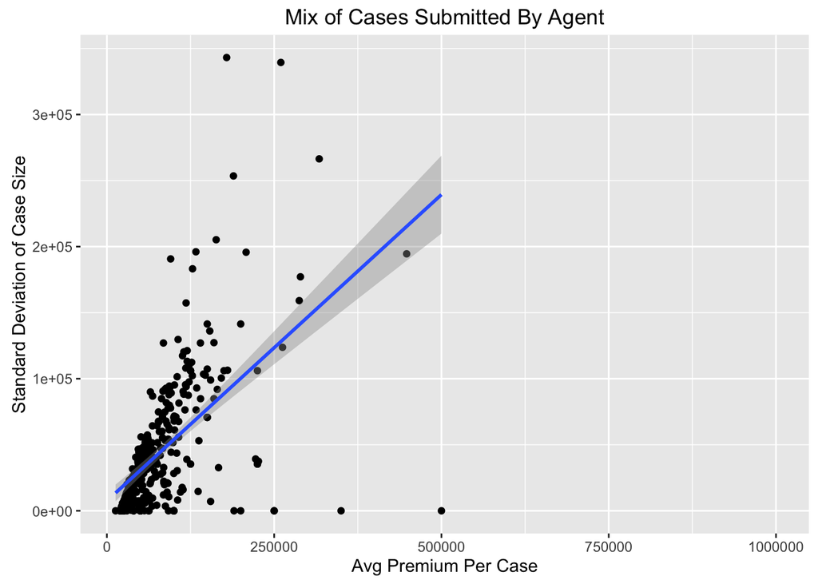

```
##
## Call:
## lm(formula = agents$St_dev ~ agents$Avg_case_size)
##
## Coefficients:
##          (Intercept)  agents$Avg_case_size
##            7509.7884                0.4637
```

```
##
## Call:
## lm(formula = agents$St_dev ~ agents$Avg_case_size)
##
## Residuals:
##     Min      1Q  Median      3Q     Max
## -239363  -16784   -3799   14884  252619
##
## Coefficients:
##                       Estimate Std. Error t value Pr(>|t|)
## (Intercept)          7.510e+03  3.584e+03   2.095   0.0368 *
## agents$Avg_case_size 4.637e-01  3.545e-02  13.080   <2e-16 ***
## ---
## Signif. codes:  0 '***' 0.001 '**' 0.01 '*' 0.05 '.' 0.1 ' ' 1
##
## Residual standard error: 40790 on 360 degrees of freedom
##   (517 observations deleted due to missingness)
## Multiple R-squared:  0.3221, Adjusted R-squared:  0.3203
## F-statistic: 171.1 on 1 and 360 DF,  p-value: < 2.2e-16
```

[figure not shown]

```
##
## Call:
## lm(formula = agents$St_dev ~ agents$Cases)
##
## Coefficients:
##  (Intercept)  agents$Cases
##        37694          1819
```

```
##
## Call:
## lm(formula = agents$St_dev ~ agents$Cases)
##
## Residuals:
##    Min     1Q Median     3Q    Max
## -48607 -34532 -13513  15066 298079
##
## Coefficients:
##              Estimate Std. Error t value Pr(>|t|)
## (Intercept)   37694.1     3581.7  10.524  < 2e-16 ***
## agents$Cases   1818.8      613.7   2.964  0.00324 **
## ---
## Signif. codes:  0 '***' 0.001 '**' 0.01 '*' 0.05 '.' 0.1 ' ' 1
##
## Residual standard error: 48950 on 360 degrees of freedom
##   (517 observations deleted due to missingness)
## Multiple R-squared:  0.02382,    Adjusted R-squared:  0.02111
## F-statistic: 8.785 on 1 and 360 DF,  p-value: 0.00324
```

## Concentration of Business

#### Distribution by Agent Sales Volume

Large cases are greater than $150,000

|  | Decile_Sales | Avg_case_size | Med_case_size | Total_sales | Avg_cases | Avg_lg_cases | Tot_Cases | St_dev |
| --- | --- | --- | --- | --- | --- | --- | --- | --- |
| 1 | 1 | 21571 | 20000 | 1898263 | 1.0 | 0.0 | 88 |  |
| 2 | 2 | 30480 | 30000 | 2775246 | 1.1 | 0.0 | 93 | 0 |
| 3 | 3 | 43399 | 50000 | 4174846 | 1.2 | 0.0 | 104 | 1346 |
| 4 | 4 | 51853 | 51000 | 5372056 | 1.3 | 0.0 | 115 | 10118 |
| 5 | 5 | 75447 | 90000 | 8180371 | 1.5 | 0.0 | 130 | 9405 |
| 6 | 6 | 85340 | 100000 | 9296562 | 1.4 | 0.0 | 127 | 24860 |
| 7 | 7 | 94761 | 77300 | 13212845 | 2.0 | 0.1 | 172 | 31616 |
| 8 | 8 | 126669 | 108836 | 18607332 | 2.2 | 0.5 | 198 | 45595 |
| 9 | 9 | 160590 | 139910 | 26972641 | 2.9 | 0.7 | 255 | 65688 |
| 10 | 10 | 171612 | 80000 | 70152683 | 8.1 | 1.2 | 705 | 80747 |

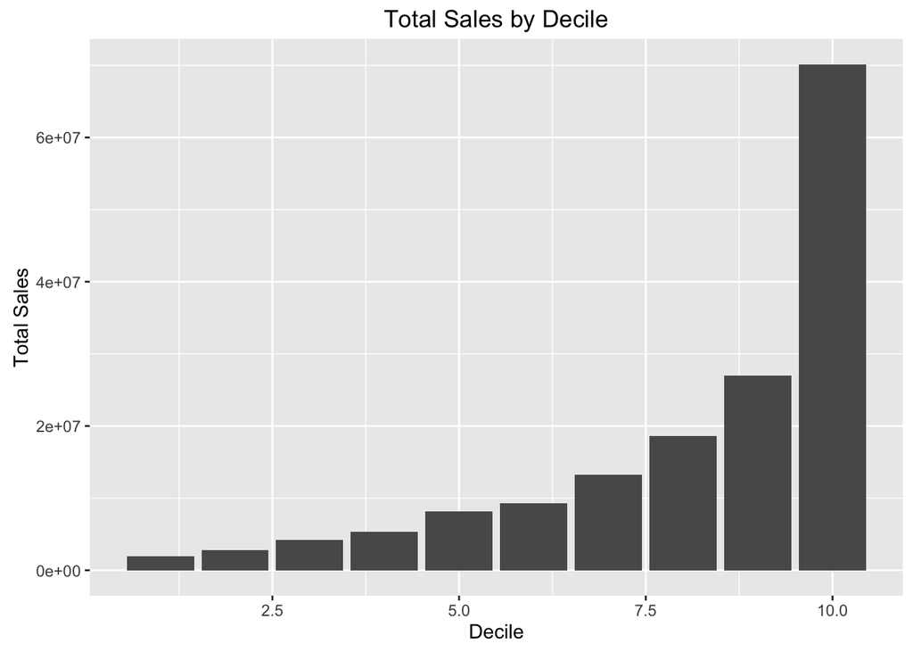

#### Distribution by Agent Case Volume

Large cases are greater than $150,000

|  | Decile_Cases | Total_cases | Avg_cases | Avg_lg_cases | Avg_case_size | Med_case_size | Total_sales | St_dev |
| --- | --- | --- | --- | --- | --- | --- | --- | --- |
| 1 | 1 | 88 | 1.0 | 0.1 | 97821 | 59926 | 8608236 |  |
| 2 | 2 | 88 | 1.0 | 0.2 | 110034 | 75000 | 9682953 |  |
| 3 | 3 | 88 | 1.0 | 0.1 | 78203 | 50000 | 6881882 |  |
| 4 | 4 | 88 | 1.0 | 0.1 | 74257 | 50000 | 6534616 |  |
| 5 | 5 | 88 | 1.0 | 0.1 | 86396 | 50000 | 7602888 |  |
| 6 | 6 | 99 | 1.1 | 0.1 | 88584 | 60500 | 8571050 | 27554 |
| 7 | 7 | 176 | 2.0 | 0.2 | 78883 | 69839 | 13883381 | 37523 |
| 8 | 8 | 180 | 2.0 | 0.4 | 97496 | 71354 | 17418982 | 40030 |
| 9 | 9 | 284 | 3.2 | 0.3 | 68794 | 50000 | 19399915 | 42038 |
| 10 | 10 | 808 | 9.3 | 0.8 | 80217 | 50000 | 62058944 | 63124 |

[figure not shown]

#### Multivariate regression model

```
##
## Call:
## lm(formula = Purchase ~ Insured.Gender + Is.1035 + Checking,
##     data = model_purchase)
##
## Residuals:
##     Min      1Q  Median      3Q     Max
## -383883  -42173  -23836   18289  933949
##
## Coefficients:
##                  Estimate Std. Error t value Pr(>|t|)
## (Intercept)     5.384e+04  3.165e+03  17.012  < 2e-16 ***
## Insured.GenderM 1.102e+04  3.804e+03   2.896  0.00382 **
## Is.1035Yes      2.292e+04  4.255e+03   5.386 8.06e-08 ***
## Checking        9.226e-02  6.042e-03  15.270  < 2e-16 ***
## ---
## Signif. codes:  0 '***' 0.001 '**' 0.01 '*' 0.05 '.' 0.1 ' ' 1
##
## Residual standard error: 84690 on 1983 degrees of freedom
## Multiple R-squared:  0.114,  Adjusted R-squared:  0.1127
## F-statistic: 85.08 on 3 and 1983 DF,  p-value: < 2.2e-16
```